# Risk Factor Analysis

## Outcome Variable

**Outcome Variable:** y_rate_len

## Predictor Variables

**Intervention Variable:** gagebrth

**Adjustment Set:**

- arm
- sex
- W_mage
- meducyrs
- feducyrs
- hhwealth_quart
- W_nrooms
- W_nchldlt5
- brthmon
- W_parity
- impfloor
- impsan
- safeh20
- delta_W_mage
- delta_meducyrs
- delta_feducyrs
- delta_hhwealth_quart
- delta_W_nrooms
- delta_W_nchldlt5
- delta_brthmon
- delta_W_parity
- delta_impfloor
- delta_impsan
- delta_safeh20

## Stratifying Variables

The analysis was stratified on these variable(s):

- agecat
- studyid
- country

## Data Summary

| agecat | studyid | country | gagebrth | n_cell | n |
| --- | --- | --- | --- | --- | --- |
| 0-3 months | ki1000108-CMC-V-BCS-2002 | INDIA | Full or late term | 53 | 86 |
| 0-3 months | ki1000108-CMC-V-BCS-2002 | INDIA | Preterm | 11 | 86 |
| 0-3 months | ki1000108-CMC-V-BCS-2002 | INDIA | Early term | 22 | 86 |
| 0-3 months | ki1000108-IRC | INDIA | Full or late term | 230 | 359 |
| 0-3 months | ki1000108-IRC | INDIA | Preterm | 36 | 359 |
| 0-3 months | ki1000108-IRC | INDIA | Early term | 93 | 359 |
| 0-3 months | ki1000109-EE | PAKISTAN | Full or late term | 40 | 594 |
| 0-3 months | ki1000109-EE | PAKISTAN | Preterm | 384 | 594 |
| 0-3 months | ki1000109-EE | PAKISTAN | Early term | 170 | 594 |
| 0-3 months | ki1000304b-SAS-CompFeed | INDIA | Full or late term | 19 | 1161 |
| 0-3 months | ki1000304b-SAS-CompFeed | INDIA | Preterm | 1061 | 1161 |
| 0-3 months | ki1000304b-SAS-CompFeed | INDIA | Early term | 81 | 1161 |
| 0-3 months | ki1017093c-NIH-Crypto | BANGLADESH | Full or late term | 162 | 720 |
| 0-3 months | ki1017093c-NIH-Crypto | BANGLADESH | Preterm | 252 | 720 |
| 0-3 months | ki1017093c-NIH-Crypto | BANGLADESH | Early term | 306 | 720 |
| 0-3 months | ki1101329-Keneba | GAMBIA | Full or late term | 598 | 1232 |
| 0-3 months | ki1101329-Keneba | GAMBIA | Preterm | 183 | 1232 |
| 0-3 months | ki1101329-Keneba | GAMBIA | Early term | 451 | 1232 |
| 0-3 months | ki1119695-PROBIT | BELARUS | Full or late term | 6507 | 12745 |
| 0-3 months | ki1119695-PROBIT | BELARUS | Preterm | 432 | 12745 |
| 0-3 months | ki1119695-PROBIT | BELARUS | Early term | 5806 | 12745 |
| 0-3 months | ki1135781-COHORTS | GUATEMALA | Full or late term | 304 | 551 |
| 0-3 months | ki1135781-COHORTS | GUATEMALA | Preterm | 87 | 551 |
| 0-3 months | ki1135781-COHORTS | GUATEMALA | Early term | 160 | 551 |
| 0-3 months | ki1135781-COHORTS | INDIA | Full or late term | 561 | 1274 |
| 0-3 months | ki1135781-COHORTS | INDIA | Preterm | 279 | 1274 |
| 0-3 months | ki1135781-COHORTS | INDIA | Early term | 434 | 1274 |
| 0-3 months | kiGH5241-JiVitA-3 | BANGLADESH | Full or late term | 17560 | 33724 |
| 0-3 months | kiGH5241-JiVitA-3 | BANGLADESH | Preterm | 6740 | 33724 |
| 0-3 months | kiGH5241-JiVitA-3 | BANGLADESH | Early term | 9424 | 33724 |

[output cut: 99 more lines]

The following strata were considered:

- agecat: 0-3 months, studyid: ki1000108-CMC-V-BCS-2002, country: INDIA
- agecat: 0-3 months, studyid: ki1000108-IRC, country: INDIA
- agecat: 0-3 months, studyid: ki1000109-EE, country: PAKISTAN
- agecat: 0-3 months, studyid: ki1000304b-SAS-CompFeed, country: INDIA
- agecat: 0-3 months, studyid: ki1017093c-NIH-Crypto, country: BANGLADESH
- agecat: 0-3 months, studyid: ki1101329-Keneba, country: GAMBIA
- agecat: 0-3 months, studyid: ki1119695-PROBIT, country: BELARUS
- agecat: 0-3 months, studyid: ki1135781-COHORTS, country: GUATEMALA
- agecat: 0-3 months, studyid: ki1135781-COHORTS, country: INDIA
- agecat: 0-3 months, studyid: kiGH5241-JiVitA-3, country: BANGLADESH
- agecat: 12-24 months, studyid: ki1000108-CMC-V-BCS-2002, country: INDIA
- agecat: 12-24 months, studyid: ki1000108-IRC, country: INDIA
- agecat: 12-24 months, studyid: ki1017093c-NIH-Crypto, country: BANGLADESH
- agecat: 12-24 months, studyid: ki1066203-TanzaniaChild2, country: TANZANIA, UNITED REPUBLIC OF
- agecat: 12-24 months, studyid: ki1101329-Keneba, country: GAMBIA
- agecat: 12-24 months, studyid: ki1119695-PROBIT, country: BELARUS
- agecat: 12-24 months, studyid: ki1135781-COHORTS, country: GUATEMALA
- agecat: 12-24 months, studyid: ki1135781-COHORTS, country: INDIA
- agecat: 12-24 months, studyid: ki1135781-COHORTS, country: PHILIPPINES
- agecat: 12-24 months, studyid: kiGH5241-JiVitA-3, country: BANGLADESH
- agecat: 3-6 months, studyid: ki1000108-CMC-V-BCS-2002, country: INDIA
- agecat: 3-6 months, studyid: ki1000108-IRC, country: INDIA
- agecat: 3-6 months, studyid: ki1000109-EE, country: PAKISTAN
- agecat: 3-6 months, studyid: ki1000304b-SAS-CompFeed, country: INDIA
- agecat: 3-6 months, studyid: ki1017093c-NIH-Crypto, country: BANGLADESH
- agecat: 3-6 months, studyid: ki1066203-TanzaniaChild2, country: TANZANIA, UNITED REPUBLIC OF
- agecat: 3-6 months, studyid: ki1101329-Keneba, country: GAMBIA
- agecat: 3-6 months, studyid: ki1119695-PROBIT, country: BELARUS
- agecat: 3-6 months, studyid: ki1135781-COHORTS, country: GUATEMALA
- agecat: 3-6 months, studyid: ki1135781-COHORTS, country: INDIA
- agecat: 3-6 months, studyid: kiGH5241-JiVitA-3, country: BANGLADESH
- agecat: 6-12 months, studyid: ki1000108-CMC-V-BCS-2002, country: INDIA
- agecat: 6-12 months, studyid: ki1000108-IRC, country: INDIA
- agecat: 6-12 months, studyid: ki1000109-EE, country: PAKISTAN
- agecat: 6-12 months, studyid: ki1000304b-SAS-CompFeed, country: INDIA
- agecat: 6-12 months, studyid: ki1017093c-NIH-Crypto, country: BANGLADESH
- agecat: 6-12 months, studyid: ki1066203-TanzaniaChild2, country: TANZANIA, UNITED REPUBLIC OF
- agecat: 6-12 months, studyid: ki1101329-Keneba, country: GAMBIA
- agecat: 6-12 months, studyid: ki1119695-PROBIT, country: BELARUS
- agecat: 6-12 months, studyid: ki1135781-COHORTS, country: GUATEMALA
- agecat: 6-12 months, studyid: ki1135781-COHORTS, country: INDIA
- agecat: 6-12 months, studyid: ki1135781-COHORTS, country: PHILIPPINES
- agecat: 6-12 months, studyid: kiGH5241-JiVitA-3, country: BANGLADESH

### Dropped Strata

Some strata were dropped due to rare outcomes:

- agecat: 6-12 months, studyid: ki1000109-EE, country: PAKISTAN
- agecat: 12-24 months, studyid: ki1066203-TanzaniaChild2, country: TANZANIA, UNITED REPUBLIC OF

## Methods Detail

We’re interested in the causal parameters $E[Y_a]$ for all values of $a \in \mathcal{A}$. These parameters represent the mean outcome if, possibly contrary to fact, we intervened to set all units to have $A=a$. Under the randomization and positivity assumptions, these are identified by the statistical parameters $\psi_a=E_W[E_{Y|A,W}(Y|A=a,W)]$. In addition, we’re interested in the mean of $Y$, $E[Y]$ under no intervention (the observed mean). We will estimate these parameters by using SuperLearner to fit the relevant likelihood factors – $E_{Y|A,W}(Y|A=a,W)$ and $p(A=a|W)$, and then updating our likelihood fit using a joint TMLE.

For unadjusted analyses ($W=\{\}$), initial likelihoods were estimated using Lrnr_glm to estimate the simple $E(Y|A)$ and Lrnr_mean to estimate $p(A)$. For adjusted analyses, a small library containing Lrnr_glmnet, Lrnr_xgboost, and Lrnr_mean was used.

Having estimated these parameters, we will then use the delta method to estimate relative risks and attributable risks relative to a prespecified baseline level of $A$.

# Results Detail

## Results Plots

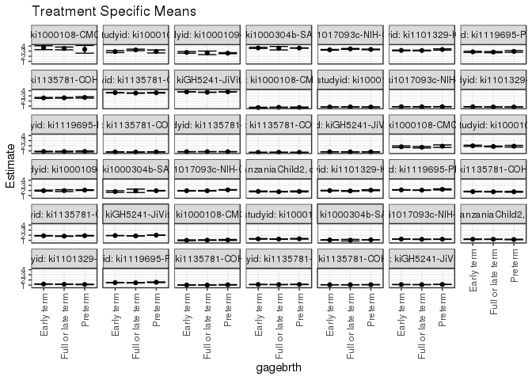

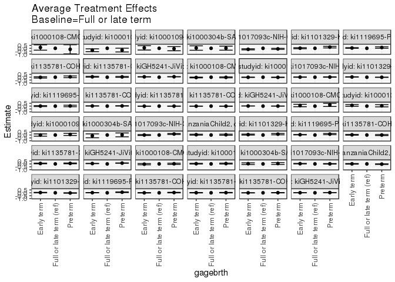

## Results Table

### Parameter: TSM

| agecat | studyid | country | intervention_level | baseline_level | estimate | ci_lower | ci_upper |
| --- | --- | --- | --- | --- | --- | --- | --- |
| 0-3 months | ki1000108-CMC-V-BCS-2002 | INDIA | Full or late term | NA | 3.5261960 | 3.2618413 | 3.7905508 |
| 0-3 months | ki1000108-CMC-V-BCS-2002 | INDIA | Preterm | NA | 3.3540586 | 2.5992486 | 4.1088685 |
| 0-3 months | ki1000108-CMC-V-BCS-2002 | INDIA | Early term | NA | 3.6669104 | 3.2868339 | 4.0469869 |
| 0-3 months | ki1000108-IRC | INDIA | Full or late term | NA | 3.2378300 | 3.0942602 | 3.3813997 |
| 0-3 months | ki1000108-IRC | INDIA | Preterm | NA | 2.9301132 | 2.6372368 | 3.2229896 |
| 0-3 months | ki1000108-IRC | INDIA | Early term | NA | 2.9034892 | 2.7095063 | 3.0974720 |
| 0-3 months | ki1000109-EE | PAKISTAN | Full or late term | NA | 2.6622688 | 2.3158050 | 3.0087327 |
| 0-3 months | ki1000109-EE | PAKISTAN | Preterm | NA | 2.5936090 | 2.5002853 | 2.6869327 |
| 0-3 months | ki1000109-EE | PAKISTAN | Early term | NA | 2.7462770 | 2.5860604 | 2.9064936 |
| 0-3 months | ki1000304b-SAS-CompFeed | INDIA | Full or late term | NA | 3.5758701 | 3.2408088 | 3.9109314 |
| 0-3 months | ki1000304b-SAS-CompFeed | INDIA | Preterm | NA | 3.6039098 | 3.5734008 | 3.6344188 |
| 0-3 months | ki1000304b-SAS-CompFeed | INDIA | Early term | NA | 3.6264819 | 3.5138162 | 3.7391476 |
| 0-3 months | ki1017093c-NIH-Crypto | BANGLADESH | Full or late term | NA | 3.4344144 | 3.3583930 | 3.5104359 |
| 0-3 months | ki1017093c-NIH-Crypto | BANGLADESH | Preterm | NA | 3.3314603 | 3.2727210 | 3.3901996 |
| 0-3 months | ki1017093c-NIH-Crypto | BANGLADESH | Early term | NA | 3.2592864 | 3.2025139 | 3.3160589 |
| 0-3 months | ki1101329-Keneba | GAMBIA | Full or late term | NA | 3.1201412 | 3.0545781 | 3.1857043 |
| 0-3 months | ki1101329-Keneba | GAMBIA | Preterm | NA | 3.3211874 | 3.2012616 | 3.4411133 |
| 0-3 months | ki1101329-Keneba | GAMBIA | Early term | NA | 3.1385121 | 3.0732725 | 3.2037517 |
| 0-3 months | ki1119695-PROBIT | BELARUS | Full or late term | NA | 2.8076121 | 2.6959415 | 2.9192827 |
| 0-3 months | ki1119695-PROBIT | BELARUS | Preterm | NA | 2.9434894 | 2.7748187 | 3.1121601 |
| 0-3 months | ki1119695-PROBIT | BELARUS | Early term | NA | 2.8631043 | 2.7434657 | 2.9827429 |
| 0-3 months | ki1135781-COHORTS | GUATEMALA | Full or late term | NA | 2.6252549 | 2.5601146 | 2.6903953 |
| 0-3 months | ki1135781-COHORTS | GUATEMALA | Preterm | NA | 2.6909221 | 2.5547835 | 2.8270607 |
| 0-3 months | ki1135781-COHORTS | GUATEMALA | Early term | NA | 2.5973778 | 2.5051009 | 2.6896547 |
| 0-3 months | ki1135781-COHORTS | INDIA | Full or late term | NA | 3.5475713 | 3.5008075 | 3.5943352 |
| 0-3 months | ki1135781-COHORTS | INDIA | Preterm | NA | 3.6035717 | 3.5401780 | 3.6669653 |
| 0-3 months | ki1135781-COHORTS | INDIA | Early term | NA | 3.6217388 | 3.5679114 | 3.6755662 |
| 0-3 months | kiGH5241-JiVitA-3 | BANGLADESH | Full or late term | NA | 3.7035795 | 3.6900880 | 3.7170710 |
| 0-3 months | kiGH5241-JiVitA-3 | BANGLADESH | Preterm | NA | 3.7855711 | 3.7642177 | 3.8069246 |
| 0-3 months | kiGH5241-JiVitA-3 | BANGLADESH | Early term | NA | 3.7717502 | 3.7534984 | 3.7900020 |

[output cut: 93 more lines]

### Parameter: E(Y)

| agecat | studyid | country | intervention_level | baseline_level | estimate | ci_lower | ci_upper |
| --- | --- | --- | --- | --- | --- | --- | --- |
| 0-3 months | ki1000108-CMC-V-BCS-2002 | INDIA | NA | NA | 3.5424620 | 3.3226559 | 3.7622681 |
| 0-3 months | ki1000108-IRC | INDIA | NA | NA | 3.1786708 | 3.0648748 | 3.2924667 |
| 0-3 months | ki1000109-EE | PAKISTAN | NA | NA | 2.6575645 | 2.5739973 | 2.7411317 |
| 0-3 months | ki1000304b-SAS-CompFeed | INDIA | NA | NA | 3.6026497 | 3.5749572 | 3.6303422 |
| 0-3 months | ki1017093c-NIH-Crypto | BANGLADESH | NA | NA | 3.3028656 | 3.2646714 | 3.3410598 |
| 0-3 months | ki1101329-Keneba | GAMBIA | NA | NA | 3.1443710 | 3.0969764 | 3.1917656 |
| 0-3 months | ki1119695-PROBIT | BELARUS | NA | NA | 2.8355739 | 2.7218468 | 2.9493011 |
| 0-3 months | ki1135781-COHORTS | GUATEMALA | NA | NA | 2.6275446 | 2.5773487 | 2.6777405 |
| 0-3 months | ki1135781-COHORTS | INDIA | NA | NA | 3.5676089 | 3.5348954 | 3.6003223 |
| 0-3 months | kiGH5241-JiVitA-3 | BANGLADESH | NA | NA | 3.7366791 | 3.7256757 | 3.7476826 |
| 3-6 months | ki1000108-CMC-V-BCS-2002 | INDIA | NA | NA | 1.8085894 | 1.7027345 | 1.9144443 |
| 3-6 months | ki1000108-IRC | INDIA | NA | NA | 1.8770590 | 1.8115784 | 1.9425395 |
| 3-6 months | ki1000109-EE | PAKISTAN | NA | NA | 2.0241201 | 1.9636505 | 2.0845898 |
| 3-6 months | ki1000304b-SAS-CompFeed | INDIA | NA | NA | 1.9372686 | 1.8951315 | 1.9794057 |
| 3-6 months | ki1017093c-NIH-Crypto | BANGLADESH | NA | NA | 2.0057973 | 1.9693775 | 2.0422170 |
| 3-6 months | ki1066203-TanzaniaChild2 | TANZANIA, UNITED REPUBLIC OF | NA | NA | 1.7930234 | 1.7563473 | 1.8296994 |
| 3-6 months | ki1101329-Keneba | GAMBIA | NA | NA | 1.9509973 | 1.9060862 | 1.9959083 |
| 3-6 months | ki1119695-PROBIT | BELARUS | NA | NA | 2.0914863 | 2.0503474 | 2.1326251 |
| 3-6 months | ki1135781-COHORTS | GUATEMALA | NA | NA | 1.7551575 | 1.7203355 | 1.7899795 |
| 3-6 months | ki1135781-COHORTS | INDIA | NA | NA | 1.8699710 | 1.8423785 | 1.8975635 |
| 3-6 months | kiGH5241-JiVitA-3 | BANGLADESH | NA | NA | 1.9120583 | 1.8998349 | 1.9242816 |
| 6-12 months | ki1000108-CMC-V-BCS-2002 | INDIA | NA | NA | 1.0679211 | 1.0201335 | 1.1157087 |
| 6-12 months | ki1000108-IRC | INDIA | NA | NA | 1.2481465 | 1.2180063 | 1.2782868 |
| 6-12 months | ki1000304b-SAS-CompFeed | INDIA | NA | NA | 1.0971201 | 1.0858336 | 1.1084065 |
| 6-12 months | ki1017093c-NIH-Crypto | BANGLADESH | NA | NA | 1.2281313 | 1.2106849 | 1.2455776 |
| 6-12 months | ki1066203-TanzaniaChild2 | TANZANIA, UNITED REPUBLIC OF | NA | NA | 1.1945105 | 1.1722780 | 1.2167429 |
| 6-12 months | ki1101329-Keneba | GAMBIA | NA | NA | 1.1776266 | 1.1570262 | 1.1982270 |
| 6-12 months | ki1119695-PROBIT | BELARUS | NA | NA | 1.4709224 | 1.4326640 | 1.5091808 |
| 6-12 months | ki1135781-COHORTS | GUATEMALA | NA | NA | 1.0213263 | 1.0014497 | 1.0412028 |
| 6-12 months | ki1135781-COHORTS | INDIA | NA | NA | 1.1028264 | 1.0847215 | 1.1209313 |
| 6-12 months | ki1135781-COHORTS | PHILIPPINES | NA | NA | 1.0678997 | 1.0556267 | 1.0801728 |
| 6-12 months | kiGH5241-JiVitA-3 | BANGLADESH | NA | NA | 1.1011985 | 1.0937157 | 1.1086814 |
| 12-24 months | ki1000108-CMC-V-BCS-2002 | INDIA | NA | NA | 0.7386817 | 0.7107419 | 0.7666215 |
| 12-24 months | ki1000108-IRC | INDIA | NA | NA | 0.8299611 | 0.8097588 | 0.8501634 |
| 12-24 months | ki1017093c-NIH-Crypto | BANGLADESH | NA | NA | 0.8755729 | 0.8637860 | 0.8873598 |
| 12-24 months | ki1101329-Keneba | GAMBIA | NA | NA | 0.8441456 | 0.8319594 | 0.8563317 |
| 12-24 months | ki1119695-PROBIT | BELARUS | NA | NA | 0.8601486 | 0.8069287 | 0.9133686 |
| 12-24 months | ki1135781-COHORTS | GUATEMALA | NA | NA | 0.7708974 | 0.7583131 | 0.7834816 |
| 12-24 months | ki1135781-COHORTS | INDIA | NA | NA | 0.8282794 | 0.8184657 | 0.8380931 |
| 12-24 months | ki1135781-COHORTS | PHILIPPINES | NA | NA | 0.7066944 | 0.6993116 | 0.7140773 |
| 12-24 months | kiGH5241-JiVitA-3 | BANGLADESH | NA | NA | 0.7936261 | 0.7876858 | 0.7995663 |

### Parameter: ATE

| agecat | studyid | country | intervention_level | baseline_level | estimate | ci_lower | ci_upper |
| --- | --- | --- | --- | --- | --- | --- | --- |
| 0-3 months | ki1000108-CMC-V-BCS-2002 | INDIA | Full or late term | Full or late term | 0.0000000 | 0.0000000 | 0.0000000 |
| 0-3 months | ki1000108-CMC-V-BCS-2002 | INDIA | Preterm | Full or late term | -0.1721375 | -0.9710302 | 0.6267553 |
| 0-3 months | ki1000108-CMC-V-BCS-2002 | INDIA | Early term | Full or late term | 0.1407144 | -0.3202116 | 0.6016403 |
| 0-3 months | ki1000108-IRC | INDIA | Full or late term | Full or late term | 0.0000000 | 0.0000000 | 0.0000000 |
| 0-3 months | ki1000108-IRC | INDIA | Preterm | Full or late term | -0.3077168 | -0.6339849 | 0.0185514 |
| 0-3 months | ki1000108-IRC | INDIA | Early term | Full or late term | -0.3343408 | -0.5758409 | -0.0928406 |
| 0-3 months | ki1000109-EE | PAKISTAN | Full or late term | Full or late term | 0.0000000 | 0.0000000 | 0.0000000 |
| 0-3 months | ki1000109-EE | PAKISTAN | Preterm | Full or late term | -0.0686598 | -0.4276977 | 0.2903780 |
| 0-3 months | ki1000109-EE | PAKISTAN | Early term | Full or late term | 0.0840081 | -0.2974088 | 0.4654250 |
| 0-3 months | ki1000304b-SAS-CompFeed | INDIA | Full or late term | Full or late term | 0.0000000 | 0.0000000 | 0.0000000 |
| 0-3 months | ki1000304b-SAS-CompFeed | INDIA | Preterm | Full or late term | 0.0280397 | -0.3202471 | 0.3763265 |
| 0-3 months | ki1000304b-SAS-CompFeed | INDIA | Early term | Full or late term | 0.0506118 | -0.3335904 | 0.4348140 |
| 0-3 months | ki1017093c-NIH-Crypto | BANGLADESH | Full or late term | Full or late term | 0.0000000 | 0.0000000 | 0.0000000 |
| 0-3 months | ki1017093c-NIH-Crypto | BANGLADESH | Preterm | Full or late term | -0.1029541 | -0.1991166 | -0.0067917 |
| 0-3 months | ki1017093c-NIH-Crypto | BANGLADESH | Early term | Full or late term | -0.1751280 | -0.2701536 | -0.0801024 |
| 0-3 months | ki1101329-Keneba | GAMBIA | Full or late term | Full or late term | 0.0000000 | 0.0000000 | 0.0000000 |
| 0-3 months | ki1101329-Keneba | GAMBIA | Preterm | Full or late term | 0.2010462 | 0.0661595 | 0.3359328 |
| 0-3 months | ki1101329-Keneba | GAMBIA | Early term | Full or late term | 0.0183709 | -0.0720375 | 0.1087792 |
| 0-3 months | ki1119695-PROBIT | BELARUS | Full or late term | Full or late term | 0.0000000 | 0.0000000 | 0.0000000 |
| 0-3 months | ki1119695-PROBIT | BELARUS | Preterm | Full or late term | 0.1358773 | 0.0082193 | 0.2635353 |
| 0-3 months | ki1119695-PROBIT | BELARUS | Early term | Full or late term | 0.0554922 | -0.0016899 | 0.1126744 |
| 0-3 months | ki1135781-COHORTS | GUATEMALA | Full or late term | Full or late term | 0.0000000 | 0.0000000 | 0.0000000 |
| 0-3 months | ki1135781-COHORTS | GUATEMALA | Preterm | Full or late term | 0.0656671 | -0.0847287 | 0.2160630 |
| 0-3 months | ki1135781-COHORTS | GUATEMALA | Early term | Full or late term | -0.0278772 | -0.1402340 | 0.0844796 |
| 0-3 months | ki1135781-COHORTS | INDIA | Full or late term | Full or late term | 0.0000000 | 0.0000000 | 0.0000000 |
| 0-3 months | ki1135781-COHORTS | INDIA | Preterm | Full or late term | 0.0560003 | -0.0227770 | 0.1347777 |
| 0-3 months | ki1135781-COHORTS | INDIA | Early term | Full or late term | 0.0741675 | 0.0028135 | 0.1455215 |
| 0-3 months | kiGH5241-JiVitA-3 | BANGLADESH | Full or late term | Full or late term | 0.0000000 | 0.0000000 | 0.0000000 |
| 0-3 months | kiGH5241-JiVitA-3 | BANGLADESH | Preterm | Full or late term | 0.0819916 | 0.0579978 | 0.1059855 |
| 0-3 months | kiGH5241-JiVitA-3 | BANGLADESH | Early term | Full or late term | 0.0681707 | 0.0473647 | 0.0889767 |

[output cut: 93 more lines]